# Predictive Diamond Price Regression Project

2025-12-05

#### *Authors: Shivum Ganesh, Max Landstrom, Arya Moghadam*

#### **In this project, we fitted a regression model with the goal to predict diamond price based on several variables. We systematically tested and selected independent variables to fit the best, most statistically significant linear model.**

## PART 1 : Data Description and Descriptive Statistics, Multiple Regression Model

```r
diamonds <- read.csv("Diamonds Prices2022.csv")
set.seed(126)
n <- 2000
idx <- sample(1:nrow(diamonds), size = n, replace = FALSE)
diamonds_sample <- diamonds[idx, ]
diamonds_sample$color <- factor(diamonds_sample$color, levels = c("J", "I", "H", "G", "F", "E", "D"))
diamonds_sample$cut <- factor(diamonds_sample$cut, levels = c("Fair", "Good", "Very Good", "Premium", "Ideal"))
diamonds_sample$clarity <- factor(diamonds_sample$clarity, levels = c("I1", "SI2", "SI1", "VS2", "VS1", "VVS2", "VVS1", "IF"))
summary(diamonds_sample)
```

```
##        X             carat              cut      color      clarity
##  Min.   :   14   Min.   :0.220   Fair     : 61   J: 97   SI1    :510
##  1st Qu.:12952   1st Qu.:0.400   Good     :185   I:200   VS2    :459
##  Median :26405   Median :0.710   Very Good:470   H:312   SI2    :356
##  Mean   :26463   Mean   :0.814   Premium  :483   G:388   VS1    :302
##  3rd Qu.:40287   3rd Qu.:1.040   Ideal    :801   F:352   VVS2   :169
##  Max.   :53923   Max.   :3.240                   E:382   VVS1   :107
##                                                  D:269   (Other): 97
##      depth           table           price               x
##  Min.   :55.00   Min.   :52.00   Min.   :  344.0   Min.   :3.900
##  1st Qu.:61.10   1st Qu.:56.00   1st Qu.:  979.8   1st Qu.:4.740
##  Median :61.90   Median :57.00   Median : 2542.5   Median :5.720
##  Mean   :61.79   Mean   :57.45   Mean   : 4009.0   Mean   :5.767
##  3rd Qu.:62.60   3rd Qu.:59.00   3rd Qu.: 5401.0   3rd Qu.:6.530
##  Max.   :72.20   Max.   :70.00   Max.   :18781.0   Max.   :9.440
##
##        y              z
##  Min.   :3.85   Min.   :2.380
##  1st Qu.:4.76   1st Qu.:2.940
##  Median :5.74   Median :3.550
##  Mean   :5.77   Mean   :3.564
##  3rd Qu.:6.50   3rd Qu.:4.030
##  Max.   :9.40   Max.   :5.970
##
```

Histograms and Bar Plots:

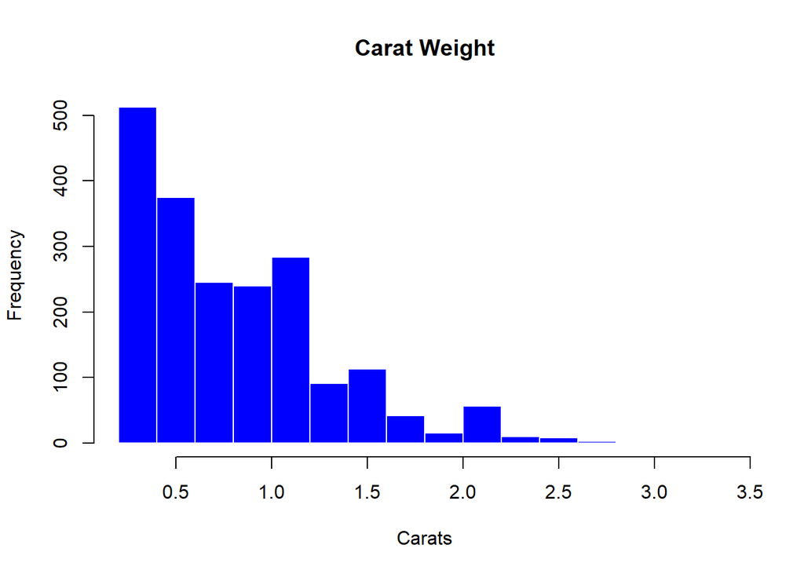

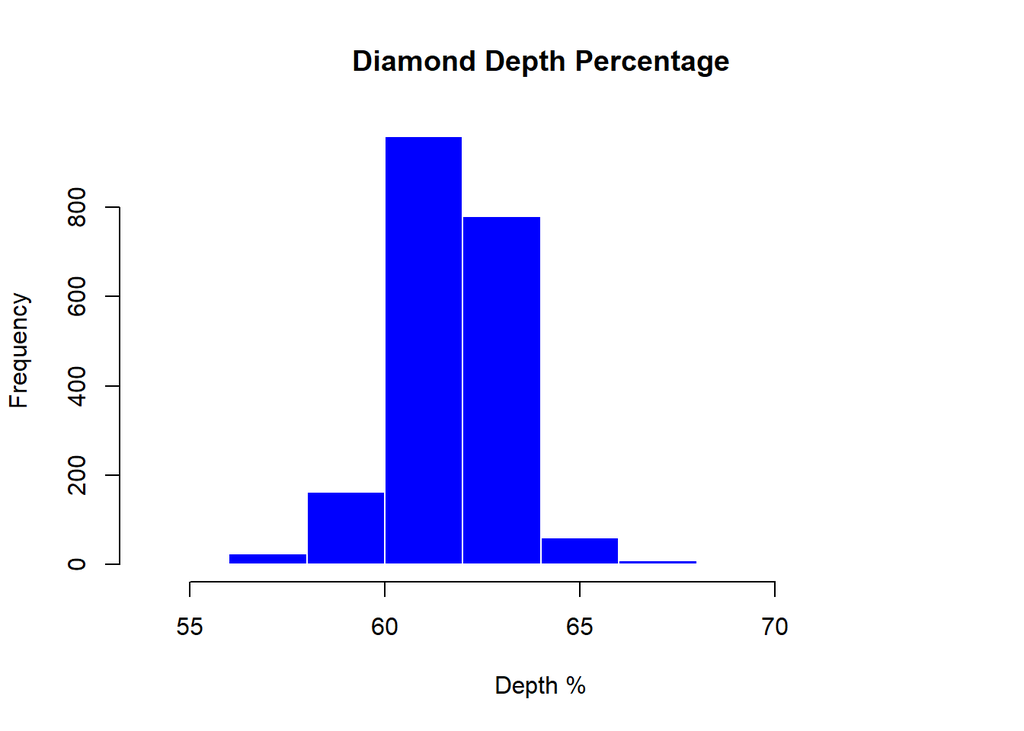

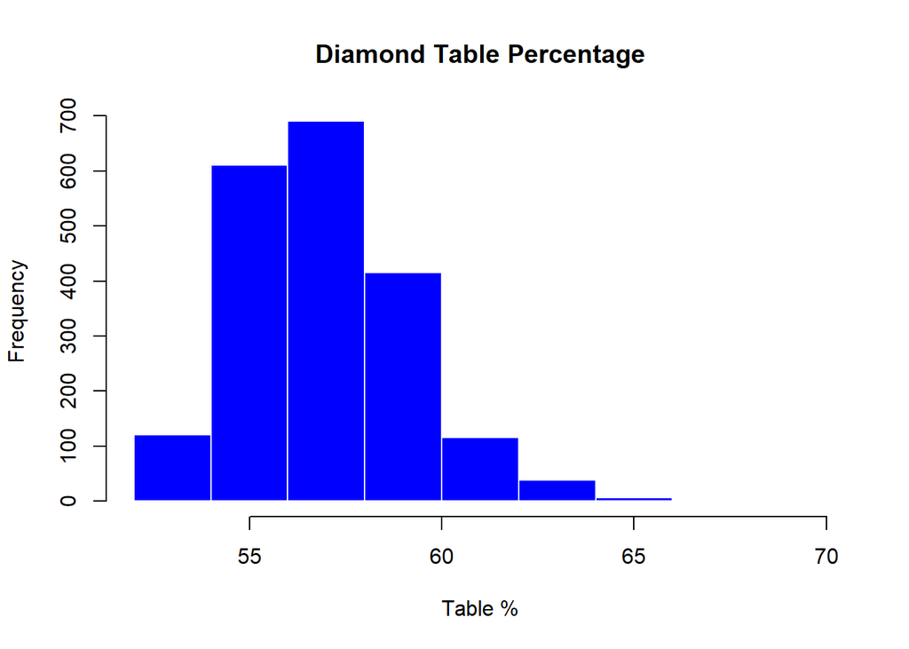

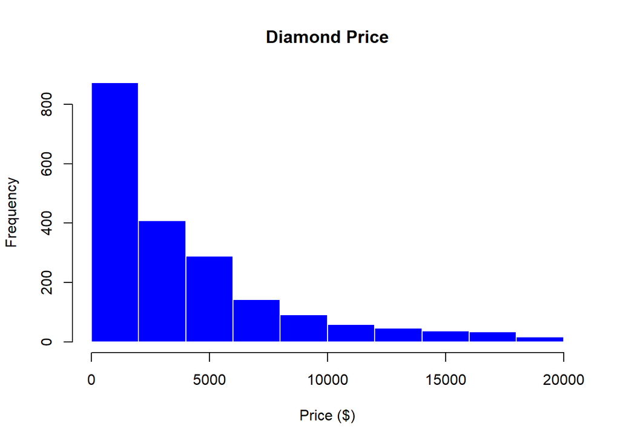

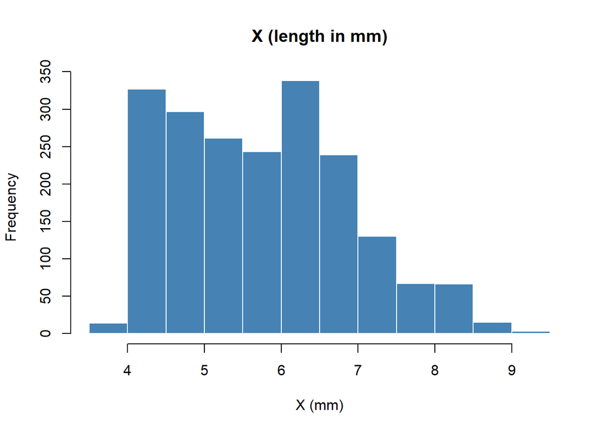

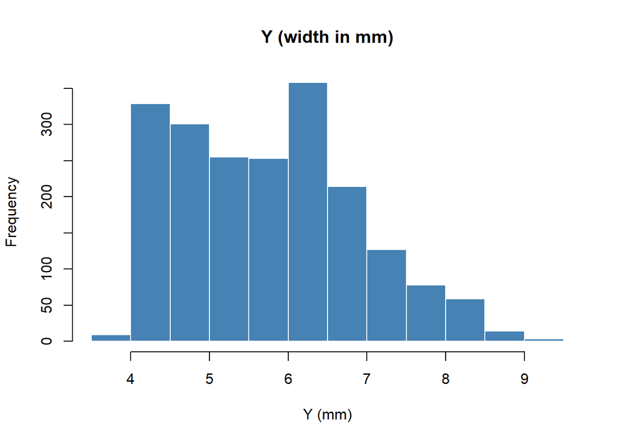

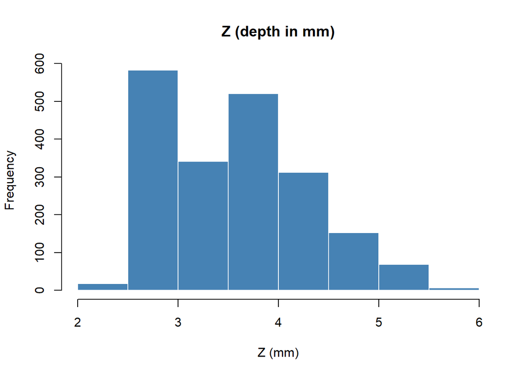

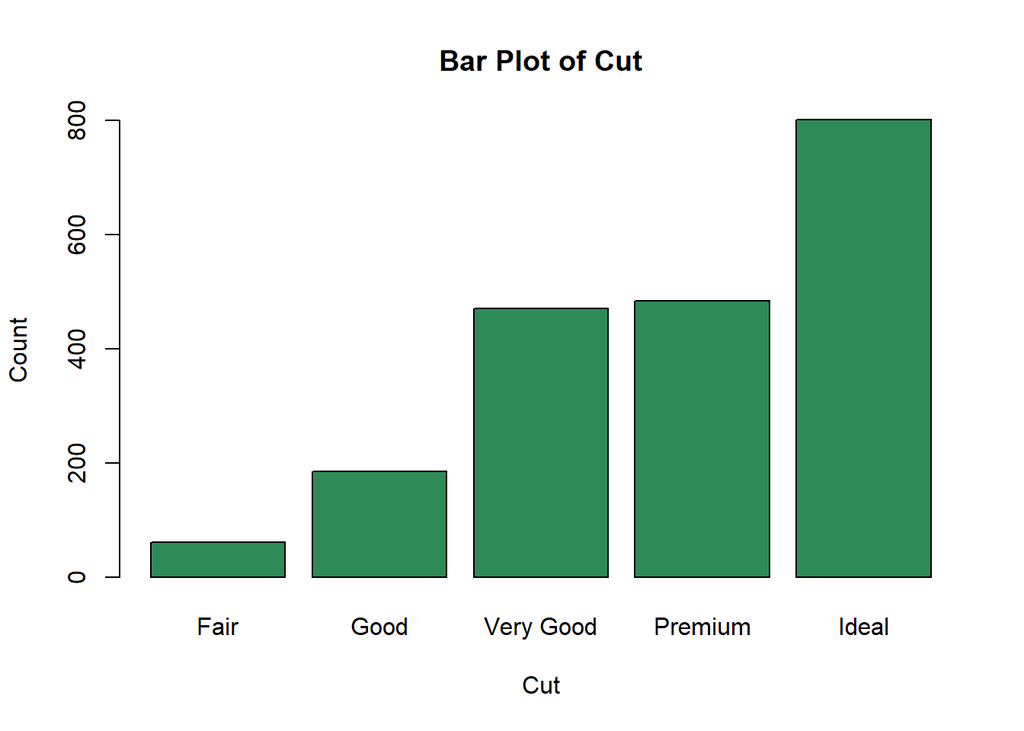

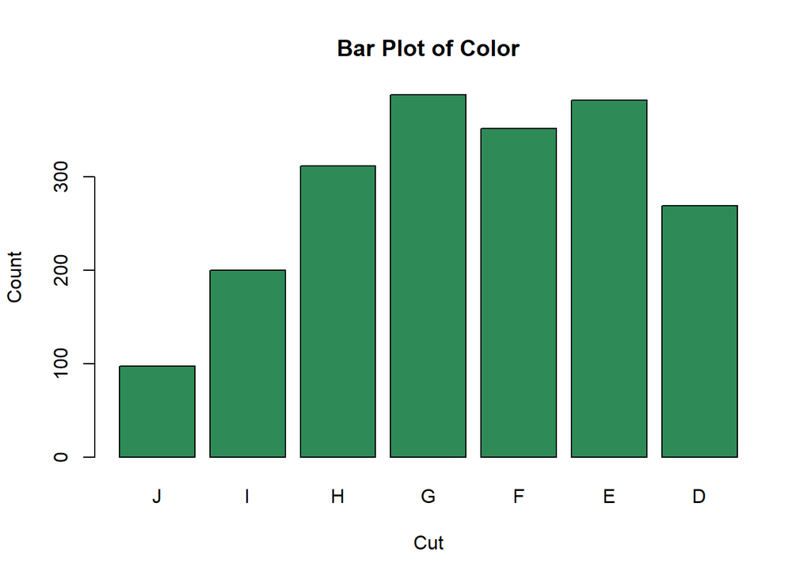

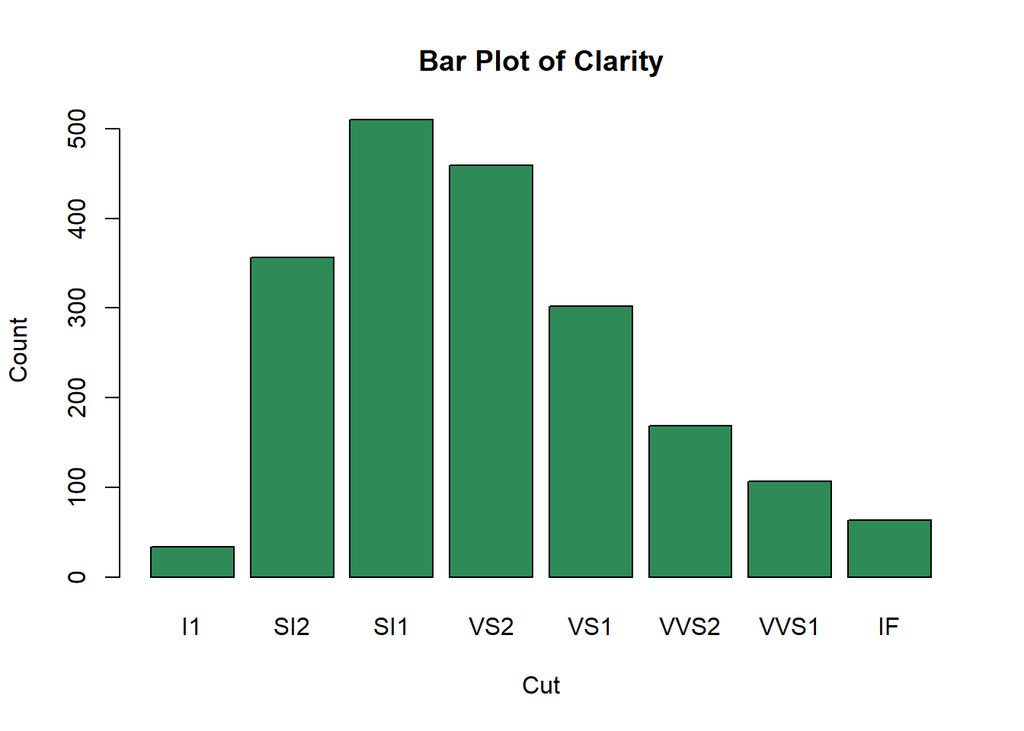

**Quantitative Variables:**

Carat: weight of the diamond. larger diamonds are more rare and valuable.

-Diamond carat weight is strongly right skewed. Many small diamonds, few large ones.

Depth: measures how tall a diamond is relative to its width.

-Diamond depth percentage is close to symmetric, slightly left-skewed, around 62.

Table: width on the top facet relative to the widest point.

-Table size is slightly right skewed, but centered near 57.

Price: diamond’s price in US dollars

-Diamond price is strongly right skewed, meaning the more expensive the diamonds, the fewer there are.

x: length of diamond in millimeters

y: width of diamond in millimeters

-y width is nearly identical tto x length in distribution. It is centered at around 6mm.

z: depth of diamond in millimeters

-z depth is similar to x and y in distribution. It is centered at around 3.5mm.

**Categorical Variables:**

Cut: Higher cut quality increases value. Levels: Fair, Good, Very Good, Premium, Ideal.

-Cut is heavily left-skewed. Each better level of cut has more frequency.

Color: Levels from D (best) to J (worst). The whiter the diamond, the more valuable.

-Color is slightly left-skewed, centered at color “G”.

Clarity: measures number and visibility of internal inclusions. Levels: I1, SI2, SI1, VS2, VS1, VVS2, VVS1, IF

-Clarity is right-skewed, with the mode being SI1.

We will use Carat, Depth and Table as our quantitative variables, and cut and color, because these are the physical properties and quality factors that are known to influence price.

```r
levels(diamonds_sample$color)
```

```
## [1] "J" "I" "H" "G" "F" "E" "D"
```

```r
model1 <- lm(price ~ carat + depth + table + cut + color, data = diamonds_sample)
summary(model1)
```

```
##
## Call:
## lm(formula = price ~ carat + depth + table + cut + color, data = diamonds_sample)
##
## Residuals:
##      Min       1Q   Median       3Q      Max
## -11719.4   -704.0    -75.0    528.1   7760.7
##
## Coefficients:
##              Estimate Std. Error t value Pr(>|t|)
## (Intercept)   1878.49    2356.03   0.797 0.425367
## carat         8089.90      70.91 114.091  < 2e-16 ***
## depth          -64.05      25.78  -2.485 0.013044 *
## table          -53.85      19.41  -2.774 0.005586 **
## cutGood        818.39     214.78   3.810 0.000143 ***
## cutVery Good  1179.09     203.31   5.799 7.73e-09 ***
## cutPremium    1066.01     205.19   5.195 2.25e-07 ***
## cutIdeal      1391.62     212.66   6.544 7.61e-11 ***
## colorI         929.33     177.05   5.249 1.69e-07 ***
## colorH         982.35     167.42   5.868 5.17e-09 ***
## colorG        1673.14     165.05  10.137  < 2e-16 ***
## colorF        1792.04     166.87  10.739  < 2e-16 ***
## colorE        1568.57     167.14   9.385  < 2e-16 ***
## colorD        1806.10     173.60  10.404  < 2e-16 ***
## ---
## Signif. codes:  0 '***' 0.001 '**' 0.01 '*' 0.05 '.' 0.1 ' ' 1
##
## Residual standard error: 1424 on 1986 degrees of freedom
## Multiple R-squared:  0.8773, Adjusted R-squared:  0.8765
## F-statistic:  1093 on 13 and 1986 DF,  p-value: < 2.2e-16
```

## PART II: Start with Simple Model

```r
lm_slr <- lm(price ~ table, data= diamonds_sample)
summary(lm_slr)
```

```
##
## Call:
## lm(formula = price ~ table, data = diamonds_sample)
##
## Residuals:
##    Min     1Q Median     3Q    Max
##  -5271  -2735  -1482   1340  15274
##
## Coefficients:
##              Estimate Std. Error t value Pr(>|t|)
## (Intercept) -11082.16    2343.56  -4.729 2.42e-06 ***
## table          262.69      40.76   6.444 1.45e-10 ***
## ---
## Signif. codes:  0 '***' 0.001 '**' 0.01 '*' 0.05 '.' 0.1 ' ' 1
##
## Residual standard error: 4013 on 1998 degrees of freedom
## Multiple R-squared:  0.02036,    Adjusted R-squared:  0.01987
## F-statistic: 41.53 on 1 and 1998 DF,  p-value: 1.453e-10
```

The model is fitted as:

price = -11082.16 + 262.69 * table

This means that for every 1 unit increase in table percentae, the price of the diamond increases by $262.69 on average. The intercept value, in theory, represents the predicted price when table percentage equals zero. But since this is impossible, the intercept does not have a practical interpretation and is instead used to define the regression line.

The Hypothesis test for the slope is:

H0: beta1 = 0, H1: beta1 does not equal 0.

The t-value is 6.444, and the p-value is near zero. Because the p-value is extremely small, we reject H0. There is strong evidence that table percentage is a predictor of price.

R-squared is 0.02, and adjusted r-squared rounds to 0.02 as well. This means that the predictor “table” alone does not explain the variance in the dependent variable. More predictors need to be added.

Confidence interval for predictor:

```r
confint(lm_slr)
```

```
##                   2.5 %     97.5 %
## (Intercept) -15678.2328 -6486.0772
## table          182.7453   342.6353
```

We are 95% confident that each 1% increase in table raises price by between 182.75 and 342.64.

Prediction interval for an individual diamond: (57% table as an example)

```r
predict(lm_slr, data.frame(table=57), interval = "prediction")
```

```
##        fit       lwr      upr
## 1 3891.193 -3980.186 11762.57
```

The prediction interval of a single diamond with table 57% is about -3980 to 11763 in value. The fact that the lower bound is negative means that this simple model does not capture the data well. This shows the weakness of the model.

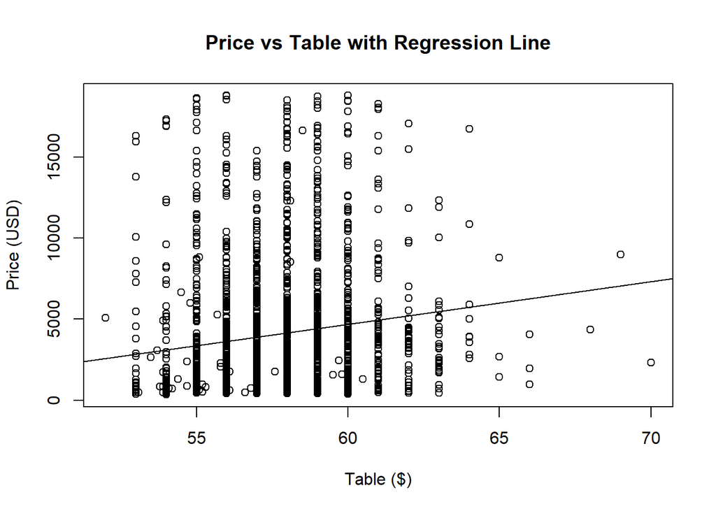

```r
plot(diamonds_sample$table, diamonds_sample$price, xlab= "Table ($)", ylab = "Price (USD)", main = "Price vs Table with Regression Line")
abline(lm_slr)
```

For this plot, the distribution is very noisy, because as we concluded, the one predictor “table” is not enough to explain the full model.

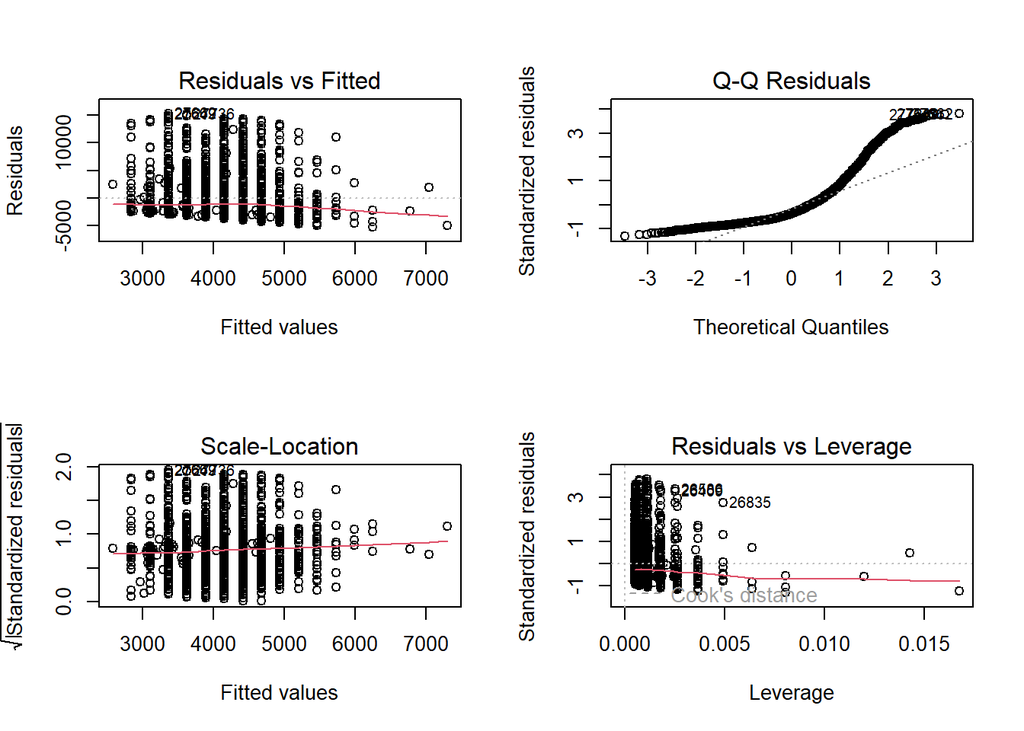

```r
par(mfrow = c(2,2))
plot(lm_slr)
```

```r
par(mfrow = c(1,1))
```

The residuals vs fitted values plot shows a curved pattern and large spread, meaning table and price do not have a strong linear relationship, so linearity assumption is not satisfied.

Residuals vs fitted shows a non-constant variance, especially as the fitted values get larger. So homoscedasticity is not present.

The normal Q-Q plot shows large tails from the straight line, so the residuals are not normally distributed.

We need to transform the price dependent variable.

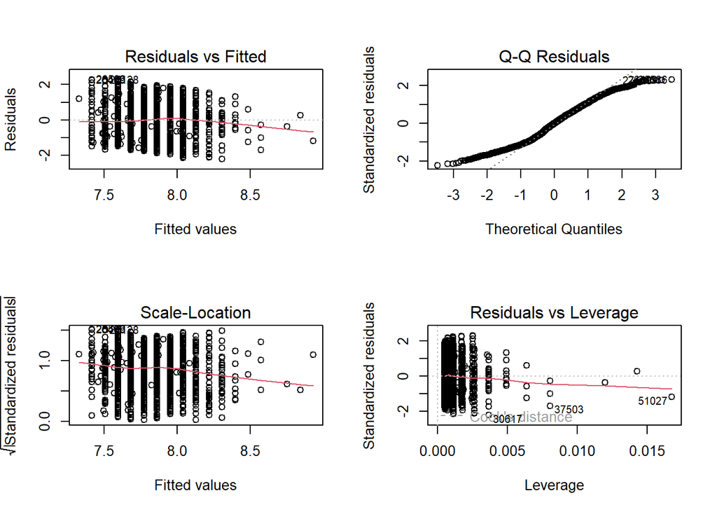

```r
lm_log <- lm(log(price) ~ table, data = diamonds_sample)

par(mfrow = c(2,2))
plot(lm_log)
```

```r
par(mfrow = c(1,1))
```

The log transformation significantly improves the integrity of the model based on the assumptions. The residuals are more symmetric and the Q-Q plot’s tails are much smaller. It’s not perfect, but the assumptions are met to a much greater degree. The log transformation should be used.

```r
summary(lm_log)
```

```
##
## Call:
## lm(formula = log(price) ~ table, data = diamonds_sample)
##
## Residuals:
##      Min       1Q   Median       3Q      Max
## -2.20457 -0.86907 -0.00013  0.75220  2.28317
##
## Coefficients:
##             Estimate Std. Error t value Pr(>|t|)
## (Intercept)  2.69142    0.57861   4.651 3.51e-06 ***
## table        0.08914    0.01006   8.857  < 2e-16 ***
## ---
## Signif. codes:  0 '***' 0.001 '**' 0.01 '*' 0.05 '.' 0.1 ' ' 1
##
## Residual standard error: 0.9907 on 1998 degrees of freedom
## Multiple R-squared:  0.03778,    Adjusted R-squared:  0.03729
## F-statistic: 78.44 on 1 and 1998 DF,  p-value: < 2.2e-16
```

The new regression summary shows a higher adjusted r-squared than the non-transformed model, suggesting a better model fit. The slope remains statistically significant, meaning the positive relationship between table and price still applies. We will now add other predictors to the model to improve our adjusted r-squared and achieve our final model.

```r
lm_multiple <- lm(log(price) ~ carat + color + clarity + x + y + z, data = diamonds_sample)
summary(lm_multiple)
```

```
##
## Call:
## lm(formula = log(price) ~ carat + color + clarity + x + y + z,
##     data = diamonds_sample)
##
## Residuals:
##      Min       1Q   Median       3Q      Max
## -0.51711 -0.08788 -0.00300  0.08607  1.73138
##
## Coefficients:
##             Estimate Std. Error t value Pr(>|t|)
## (Intercept) -0.63023    0.06205 -10.157  < 2e-16 ***
## carat       -1.14273    0.03208 -35.622  < 2e-16 ***
## colorI       0.12549    0.01770   7.088 1.88e-12 ***
## colorH       0.24805    0.01682  14.751  < 2e-16 ***
## colorG       0.32262    0.01658  19.454  < 2e-16 ***
## colorF       0.41433    0.01678  24.695  < 2e-16 ***
## colorE       0.45083    0.01681  26.811  < 2e-16 ***
## colorD       0.49508    0.01748  28.317  < 2e-16 ***
## claritySI2   0.41421    0.02579  16.061  < 2e-16 ***
## claritySI1   0.57167    0.02565  22.285  < 2e-16 ***
## clarityVS2   0.71320    0.02578  27.670  < 2e-16 ***
## clarityVS1   0.78235    0.02635  29.693  < 2e-16 ***
## clarityVVS2  0.91145    0.02742  33.236  < 2e-16 ***
## clarityVVS1  0.98550    0.02890  34.104  < 2e-16 ***
## clarityIF    1.05468    0.03113  33.876  < 2e-16 ***
## x            0.68753    0.06331  10.860  < 2e-16 ***
## y            0.23808    0.06196   3.843 0.000126 ***
## z            0.85023    0.03749  22.678  < 2e-16 ***
## ---
## Signif. codes:  0 '***' 0.001 '**' 0.01 '*' 0.05 '.' 0.1 ' ' 1
##
## Residual standard error: 0.1425 on 1982 degrees of freedom
## Multiple R-squared:  0.9803, Adjusted R-squared:  0.9801
## F-statistic:  5791 on 17 and 1982 DF,  p-value: < 2.2e-16
```

Best Model (from the summary function):

```r
library(car)
vif(lm_multiple)
```

```
##               GVIF Df GVIF^(1/(2*Df))
## carat    24.333501  1        4.932900
## color     1.239050  6        1.018023
## clarity   1.346651  7        1.021486
## x       503.804870  1       22.445598
## y       474.703475  1       21.787691
## z        67.578974  1        8.220643
```

GVIF for:

X: 504

Y: 475

Z: 68

All of these are extremely high, indicating high multicollinearity. This is likely the cause of the estimate for carat being negative, which doesn’t make sense logically (bigger diamonds tend to be more expensive). so, we will keep carat and remove x, y, and z.

```r
lm_final <- lm(log(price) ~ carat + color + clarity, data = diamonds_sample)
summary(lm_final)
```

```
##
## Call:
## lm(formula = log(price) ~ carat + color + clarity, data = diamonds_sample)
##
## Residuals:
##      Min       1Q   Median       3Q      Max
## -2.61194 -0.23878  0.06946  0.26313  1.52339
##
## Coefficients:
##             Estimate Std. Error t value Pr(>|t|)
## (Intercept)  4.91675    0.07959  61.775  < 2e-16 ***
## carat        2.09138    0.01906 109.698  < 2e-16 ***
## colorI       0.12540    0.04500   2.786  0.00538 **
## colorH       0.33646    0.04263   7.893 4.85e-15 ***
## colorG       0.40752    0.04208   9.684  < 2e-16 ***
## colorF       0.52666    0.04256  12.374  < 2e-16 ***
## colorE       0.51243    0.04271  11.998  < 2e-16 ***
## colorD       0.53139    0.04443  11.960  < 2e-16 ***
## claritySI2   0.59571    0.06527   9.127  < 2e-16 ***
## claritySI1   0.74256    0.06483  11.454  < 2e-16 ***
## clarityVS2   0.84115    0.06519  12.903  < 2e-16 ***
## clarityVS1   0.90605    0.06659  13.606  < 2e-16 ***
## clarityVVS2  0.95467    0.06942  13.753  < 2e-16 ***
## clarityVVS1  0.92288    0.07300  12.643  < 2e-16 ***
## clarityIF    1.00643    0.07854  12.814  < 2e-16 ***
## ---
## Signif. codes:  0 '***' 0.001 '**' 0.01 '*' 0.05 '.' 0.1 ' ' 1
##
## Residual standard error: 0.3622 on 1985 degrees of freedom
## Multiple R-squared:  0.8722, Adjusted R-squared:  0.8713
## F-statistic:   968 on 14 and 1985 DF,  p-value: < 2.2e-16
```

```r
vif(lm_final)
```

```
##             GVIF Df GVIF^(1/(2*Df))
## carat   1.329759  1        1.153152
## color   1.208476  6        1.015905
## clarity 1.261944  7        1.016757
```

Removing the dimensions from the model allowed VIF to drop to healthy levels, around 1.3 for the three remaining predictors. However, the adjusted r-squared decreased significantly. Running the diagnostics, we see that residuals vs. fitted values shows a curved pattern, meaning the relationship between carat and log(price) is not linear. So, we will log-transform carat as well.

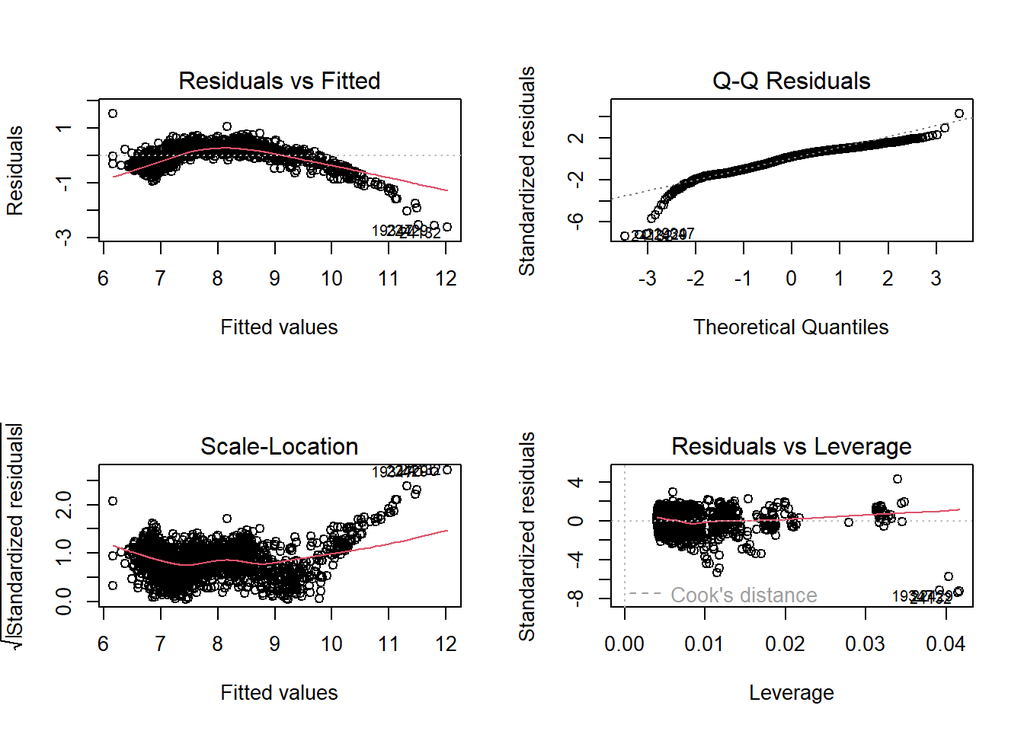

```r
par(mfrow = c(2,2))
plot(lm_final)
```

```r
par(mfrow = c(1,1))
```

```r
lm_log_final <- lm(log(price) ~ log(carat) + color + clarity, data = diamonds_sample)
summary(lm_log_final)
```

```
##
## Call:
## lm(formula = log(price) ~ log(carat) + color + clarity, data = diamonds_sample)
##
## Residuals:
##      Min       1Q   Median       3Q      Max
## -0.77084 -0.08953 -0.00273  0.08659  1.81712
##
## Coefficients:
##             Estimate Std. Error t value Pr(>|t|)
## (Intercept) 7.453419   0.029702 250.937  < 2e-16 ***
## log(carat)  1.872357   0.006483 288.794  < 2e-16 ***
## colorI      0.134875   0.018232   7.398 2.03e-13 ***
## colorH      0.253112   0.017222  14.697  < 2e-16 ***
## colorG      0.329088   0.016970  19.392  < 2e-16 ***
## colorF      0.427238   0.017139  24.927  < 2e-16 ***
## colorE      0.456038   0.017194  26.524  < 2e-16 ***
## colorD      0.498915   0.017907  27.861  < 2e-16 ***
## claritySI2  0.458585   0.026423  17.356  < 2e-16 ***
## claritySI1  0.623182   0.026204  23.782  < 2e-16 ***
## clarityVS2  0.767832   0.026347  29.143  < 2e-16 ***
## clarityVS1  0.838310   0.026900  31.164  < 2e-16 ***
## clarityVVS2 0.968905   0.028076  34.510  < 2e-16 ***
## clarityVVS1 1.044184   0.029584  35.296  < 2e-16 ***
## clarityIF   1.123265   0.031831  35.289  < 2e-16 ***
## ---
## Signif. codes:  0 '***' 0.001 '**' 0.01 '*' 0.05 '.' 0.1 ' ' 1
##
## Residual standard error: 0.1467 on 1985 degrees of freedom
## Multiple R-squared:  0.979,  Adjusted R-squared:  0.9789
## F-statistic:  6618 on 14 and 1985 DF,  p-value: < 2.2e-16
```

```r
vif(lm_log_final)
```

```
##                GVIF Df GVIF^(1/(2*Df))
## log(carat) 1.333908  1        1.154949
## color      1.182360  6        1.014057
## clarity    1.294198  7        1.018592
```

As we thought, the log-transformation of carat makes the model fit much better, with an R-squared and adj R-squared of 0.979, meaning 97.9% of the variance in price is explained by the regression of these predictors. The VIF remains low, meaning multicollinearity is still not an issue. Residual standard error is still very low, meaning the overall fit of the model is very accurate. The p-value of the f-statistic is near zero, indicating that the use of the model as a whole to explain the variance of price is significant. All of these confirm that this is the correct final model:

[figure not shown]

**Confidence and Prediction Intervals:**

```r
new_diamond <- data.frame(
  carat = 1.0,
  color = "G",
  clarity = "VS1"
)


ci_log <- predict(lm_log_final, newdata = new_diamond, interval = "confidence", level = 0.95)

pi_log <- predict(lm_log_final, newdata = new_diamond, interval = "prediction", level = 0.95)


CI_dollars <- exp(ci_log)
PI_dollars <- exp(pi_log)

CI_dollars
```

```
##        fit      lwr      upr
## 1 5545.918 5425.942 5668.548
```

```r
PI_dollars
```

```
##        fit      lwr      upr
## 1 5545.918 4155.505 7401.557
```

As an example, we used a new diamond tat has carat weight of 1, “G” color, and “VS1” clarity. We derived the confidence and prediction intervals:

CI: ($5426 - $5669)

PI: ($4156-$7402)

The CI indicates that we are 95% confident that the average market price for this diamond falls between $5426 and $5669.

The PI indicates that we are 95% confident that if this specific diamond is picked up tomorrow, its price falls between $4156 and $7402.

## Conclusion

In this final project, we took a sample of 2,000 diamonds to determine which factors actually explain price. We started by checking the distributions and quickly noticed that price and carat were skewed, while color and clarity differed widely. A simple model using table percentages didn’t work so well, so we moved to multiple regression. After removing x, y, and z because of extreme multicollinearity and log transforming price and carat, the model improved a lot. The final model using log carat, color, and clarity explained about 98% of the price variation, and all other predictors were clearly meaningful. Overall, carat was the strongest driver of price, with color and clarity also being useful adjustments. This gave us a solid and dependable model for predicting diamond values.